# Topic 05 Word Reference

Julia Parish

2022-05-03

# Word Reference

This text sentiment analysis was completed as an assignment for the course, Environmental Data Science 231: Text and Sentiment Analysis for Environmental Problems. The data was sourced from articles written by the Environmental Protection Agency.

Original assignment instructions can be found [here](https://maro406.github.io/EDS_231-text-sentiment/topic_5.html)

### Load Libraries

```r
library(tidyr) #text analysis in R
library(pdftools)
library(lubridate) #working with date data
library(tidyverse)
library(tidytext)
library(readr)
library(quanteda)
library(readtext) #quanteda subpackage for reading pdf
library(quanteda.textstats)
library(quanteda.textplots)
library(ggplot2)
library(forcats)
library(stringr)
library(quanteda.textplots)
library(widyr)# pairwise correlations
library(igraph) #network plots
library(ggraph)
library(here)
```

```r
setwd("/Users/julia/Documents/_MEDS/04_spring/EDS231_TextSentiment/repository/EDS231_TextSentimentAnalysis/assignments/HW05_WordReference")
```

# Assignment Set Up

## Read in data files, clean the data, create objects, and conduct frequency statistics

Load Data Files

```r
files <- list.files(path = "data/", pattern = "pdf$", full.names = T)

ej_reports <- lapply(files, pdf_text)

ej_pdf <- readtext(file = "data/*.pdf", docvarsfrom = "filenames",
                    docvarnames = c("type", "subj", "year"),
                    sep = "_")

#create an initial corpus containing the EPA EJ data
epa_corp <- corpus(x = ej_pdf, text_field = "text" )
summary(epa_corp)
```

```
## Corpus consisting of 6 documents, showing 6 documents:
##
##             Text Types Tokens Sentences type subj year
##  EPA_EJ_2015.pdf  2136   8944       263  EPA   EJ 2015
##  EPA_EJ_2016.pdf  1599   7965       176  EPA   EJ 2016
##  EPA_EJ_2017.pdf  2774  16658       447  EPA   EJ 2017
##  EPA_EJ_2018.pdf  3973  30564       653  EPA   EJ 2018
##  EPA_EJ_2019.pdf  3773  22648       672  EPA   EJ 2019
##  EPA_EJ_2020.pdf  4493  30523       987  EPA   EJ 2020
```

Add Stop Words

```r
# add context-specific stop words to stop word lexicon
more_stops <-c("2015","2016", "2017", "2018", "2019", "2020", "www.epa.gov", "https")

add_stops<- tibble(word = c(stop_words$word, more_stops))

stop_vec <- as_vector(add_stops)
```

Create different data objects for the subsequent analyses

```r
#convert to tidy format and apply my stop words
raw_text <- tidy(epa_corp)

#Distribution of most frequent words across documents
raw_words <- raw_text %>%
  mutate(year = as.factor(year)) %>%
  unnest_tokens(word, text) %>%
  anti_join(add_stops, by = 'word') %>%
  count(year, word, sort = TRUE)
```

```r
#number of total words by document
total_words <- raw_words %>%
  group_by(year) %>%
  summarize(total = sum(n))

report_words <- left_join(raw_words, total_words)

par_tokens <- unnest_tokens(raw_text, output = paragraphs, input = text, token = "paragraphs")

par_tokens <- par_tokens %>%
 mutate(par_id = 1:n())

par_words <- unnest_tokens(par_tokens, output = word, input = paragraphs, token = "words")
```

```r
tokens <- tokens(epa_corp, remove_punct = TRUE)
toks1<- tokens_select(tokens, min_nchar = 3)
toks1 <- tokens_tolower(toks1)
toks1 <- tokens_remove(toks1, pattern = (stop_vec))
dfm <- dfm(toks1)
```

Conduct Frequency Statistics

```r
#first the basic frequency statistics
tstat_freq <- textstat_frequency(dfm, n = 5, groups = year)

head(tstat_freq, 10) %>%
  knitr::kable(caption = "Subset of Top 10 Words")
```

Subset of Top 10 Words

| feature | frequency | rank | docfreq | group |
| --- | --- | --- | --- | --- |
| environmental | 127 | 1 | 1 | 2015 |
| communities | 99 | 2 | 1 | 2015 |
| epa | 92 | 3 | 1 | 2015 |
| justice | 84 | 4 | 1 | 2015 |
| community | 47 | 5 | 1 | 2015 |
| environmental | 109 | 1 | 1 | 2016 |
| communities | 85 | 2 | 1 | 2016 |
| justice | 71 | 3 | 1 | 2016 |
| epa | 48 | 4 | 1 | 2016 |
| federal | 31 | 5 | 1 | 2016 |

# Assignment Questions

## 1. What are the most frequent trigrams in the dataset? How does this compare to the most frequent bigrams? Which n-gram seems more informative here, and why?

```r
# bigrams
toks2 <- tokens_ngrams(toks1, n=2)
dfm2 <- dfm(toks2) # document feature matrix
dfm2 <- dfm_remove(dfm2, pattern = c(stop_vec))

freq_words2 <- textstat_frequency(dfm2, n=20)
freq_words2$token <- rep("bigram", 20)

bigrams <- freq_words2 %>%
  knitr::kable(caption = "Bigrams")

bigrams
```

Bigrams

| feature | frequency | rank | docfreq | group | token |
| --- | --- | --- | --- | --- | --- |
| environmental_justice | 556 | 1 | 6 | all | bigram |
| technical_assistance | 139 | 2 | 6 | all | bigram |
| drinking_water | 133 | 3 | 6 | all | bigram |
| public_health | 123 | 4 | 6 | all | bigram |
| progress_report | 108 | 5 | 6 | all | bigram |
| air_quality | 73 | 6 | 6 | all | bigram |
| water_systems | 66 | 7 | 6 | all | bigram |
| vulnerable_communities | 65 | 8 | 6 | all | bigram |
| epa_region | 62 | 9 | 5 | all | bigram |
| environmental_public | 57 | 10 | 6 | all | bigram |
| federal_agencies | 56 | 11 | 6 | all | bigram |
| national_environmental | 51 | 12 | 6 | all | bigram |
| justice_fy2017 | 51 | 12 | 1 | all | bigram |
| fy2017_progress | 51 | 12 | 1 | all | bigram |
| superfund_sites | 48 | 15 | 4 | all | bigram |
| indigenous_peoples | 46 | 16 | 6 | all | bigram |
| civil_rights | 46 | 16 | 5 | all | bigram |
| local_governments | 45 | 18 | 6 | all | bigram |
| urban_waters | 44 | 19 | 6 | all | bigram |
| overburdened_communities | 43 | 20 | 6 | all | bigram |

```r
# trigrams
toks3 <- tokens_ngrams(toks1, n=3)
dfm3 <- dfm(toks3) # document feature matrix
dfm3 <- dfm_remove(dfm3, pattern = c(stop_vec))

freq_words3 <- textstat_frequency(dfm3, n=20)
freq_words3$token <- rep("trigram", 20)

trigrams <- freq_words3 %>%
  knitr::kable(caption = "Trigrams")

trigrams
```

Trigrams

| feature | frequency | rank | docfreq | group | token |
| --- | --- | --- | --- | --- | --- |
| justice_fy2017_progress | 51 | 1 | 1 | all | trigram |
| fy2017_progress_report | 51 | 1 | 1 | all | trigram |
| environmental_public_health | 50 | 3 | 6 | all | trigram |
| environmental_justice_fy2017 | 50 | 3 | 1 | all | trigram |
| national_environmental_justice | 37 | 5 | 6 | all | trigram |
| office_environmental_justice | 32 | 6 | 6 | all | trigram |
| epa’s_environmental_justice | 32 | 6 | 6 | all | trigram |
| environmental_justice_progress | 30 | 8 | 4 | all | trigram |
| justice_progress_report | 30 | 8 | 4 | all | trigram |
| environmental_justice_concerns | 30 | 8 | 5 | all | trigram |
| drinking_water_systems | 29 | 11 | 5 | all | trigram |
| annual_environmental_justice | 27 | 12 | 5 | all | trigram |
| environmental_justice_advisory | 27 | 12 | 6 | all | trigram |
| fiscal_annual_environmental | 25 | 14 | 3 | all | trigram |
| justice_advisory_council | 24 | 15 | 6 | all | trigram |
| environmental_justice_grants | 22 | 16 | 5 | all | trigram |
| technical_assistance_communities | 20 | 17 | 6 | all | trigram |
| communities_environmental_justice | 20 | 17 | 5 | all | trigram |
| safe_drinking_water | 19 | 19 | 5 | all | trigram |
| technical_assistance_services | 19 | 19 | 5 | all | trigram |

The five most frequent trigrams are justice_fy2017_progress, fy2017_progress_report, environmental_public_health, environmental_justice_fy2017, and national_environmental_justice.

The five most frequent bigrams are environmental_justice, technical_assistance, drinking_water, public_health, and progress_report.

The words `environmental`, `justice`, `water`, `progress`, and `epa` appear frequently in both the bigrams and trigrams lists. The `bigrams` list provides more detailed, diverse words relevant to EPA policy. The `trigrams` list focuses more on progress report tokens than policy terms.

## 2. Choose a new focal term to replace “justice” and recreate the correlation table and network (see corr_paragraphs and corr_network chunks). Explore some of the plotting parameters in the cor_network chunk to see if you can improve the clarity or amount of information your plot conveys. Make sure to use a different color for the ties!

```r
# pairwise correlation

word_cors <- par_words %>%
  add_count(par_id) %>%
  filter(n >= 50) %>%
  select(-n) %>%
  pairwise_cor(word, par_id, sort = TRUE)
```

```r
# filter for the term 'indigenous'
indigenous_cors <- word_cors %>%
  filter(item1 == "indigenous") %>%
  mutate(n = 1:n())
```

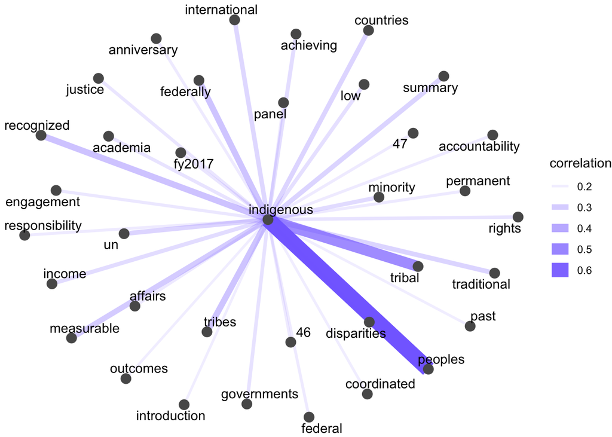

```r
# create correlation network

cor_network <- indigenous_cors  %>%
  filter(n <= 35) %>%
  graph_from_data_frame() %>%
  ggraph(layout = "fr") +
  geom_edge_link(aes(edge_alpha = correlation, edge_width = correlation), edge_colour = "lightslateblue") +
  geom_node_point(color = "grey35", size = 3.5) +
  geom_node_text(aes(label = name), repel = TRUE,
                 point.padding = unit(0.2, "lines")) +
  theme_void()

cor_network
```

## 3. Write a function that allows you to conduct a keyness analysis to compare two individual EPA reports (hint: that means target and reference need to both be individual reports). Run the function on 3 pairs of reports, generating 3 keyness plots.

Create the function

```r
keyness_function <- function(reference_report, target_report) {
  files <- list.files(path = "data/", pattern = "pdf$", full.names = T)
  ej_reports <- lapply(files, pdf_text)
  ej_pdf <- readtext(file = "data/*.pdf", docvarsfrom = "filenames",
                    docvarnames = c("type", "subj", "year"),
                    sep = "_")
  epa_corp <- corpus(x = ej_pdf, text_field = "text")
  tokens <- tokens(epa_corp, remove_punct = TRUE)
  toks1<- tokens_select(tokens, min_nchar = 3)
  toks1 <- tokens_tolower(toks1)
  toks1 <- tokens_remove(toks1, pattern = (stop_vec))
  dfm <- dfm(toks1)

  keyness_function_plot <- dfm %>%
    dfm_subset(year %in% c(reference_report, target_report)) %>%
    textstat_keyness(target = paste0("EPA_EJ_", target_report, ".pdf")) %>%
    textplot_keyness()
  keyness_function_plot
  }
```

Use function to analyze EPA Reports 2015 & 2016

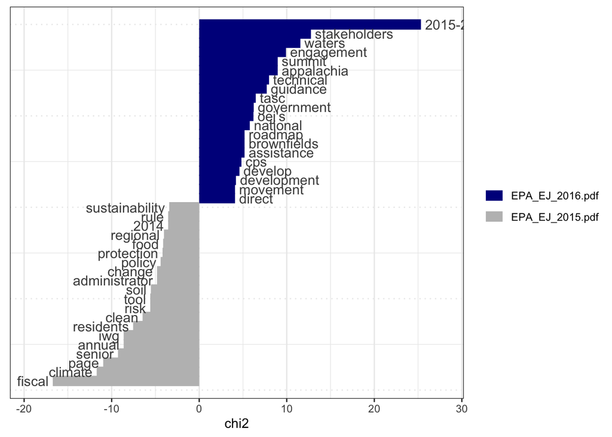

Analysis of most frequent terms in the reference file, EPA FY2015, and target file, EPA FY2016.

```r
keyness_function(reference_report = 2015, target_report = 2016)
```

Analyze EPA Reports 2016 & 2017

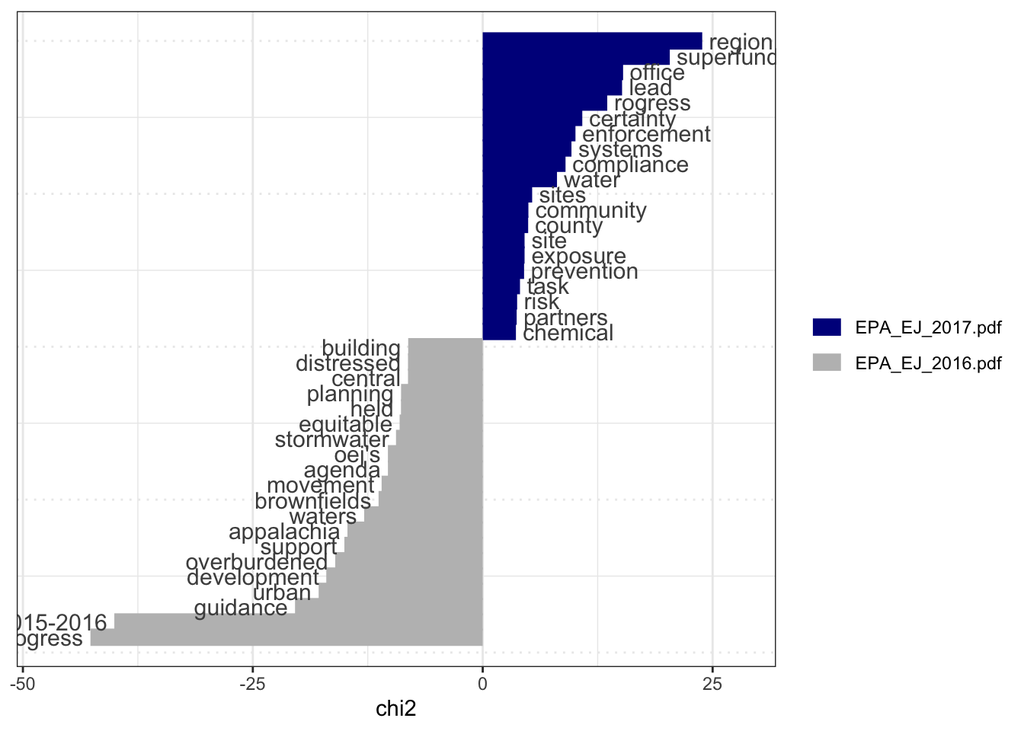

Analysis of most frequent terms in the reference file, EPA FY2016, and target file, EPA FY2017.

```r
keyness_function(reference_report = 2016, target_report = 2017)
```

Analyze EPA Reports 2017 & 2018

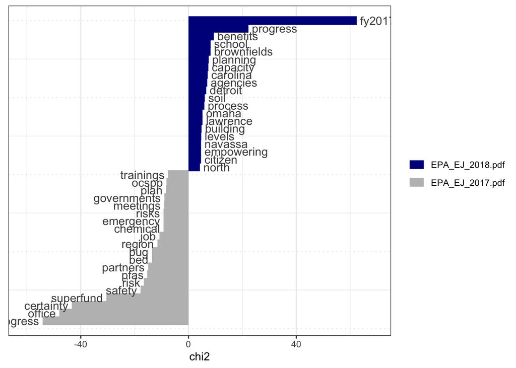

Analysis of msot frequent terms in the reference file, EPA FY2017, and target file, EPA FY2018.

```r
keyness_function(reference_report = 2017, target_report = 2018)
```

## 4. Select a word or multi-word term of interest and identify words related to it using windowing and keyness comparison. To do this you will create to objects: one containing all words occurring within a 10-word window of your term of interest, and the second object containing all other words. Then run a keyness comparison on these objects. Which one is the target, and which the reference? [Hint](https://tutorials.quanteda.io/advanced-operations/target-word-collocations/)